# MPG Analysis of Transmission Type in Motor Trend Data

## Load Data

Perform an initial data load while setting the appropriate columns as factors

```r
data(mtcars)
mtcars$am <- factor(mtcars$am, labels=c('Automatic', 'Manual'))
mtcars$cyl <- factor(mtcars$cyl)
mtcars$vs <- factor(mtcars$vs)
mtcars$gear <- factor(mtcars$gear)
mtcars$carb <- factor(mtcars$carb)
```

## Regression Model

I used model nesting and variance inflation to determine the right mode to use.

### Summary of mtcars Data

```r
summary(mtcars)
```

```
##       mpg       cyl         disp             hp             drat
##  Min.   :10.4   4:11   Min.   : 71.1   Min.   : 52.0   Min.   :2.76
##  1st Qu.:15.4   6: 7   1st Qu.:120.8   1st Qu.: 96.5   1st Qu.:3.08
##  Median :19.2   8:14   Median :196.3   Median :123.0   Median :3.69
##  Mean   :20.1          Mean   :230.7   Mean   :146.7   Mean   :3.60
##  3rd Qu.:22.8          3rd Qu.:326.0   3rd Qu.:180.0   3rd Qu.:3.92
##  Max.   :33.9          Max.   :472.0   Max.   :335.0   Max.   :4.93
##        wt            qsec      vs             am     gear   carb
##  Min.   :1.51   Min.   :14.5   0:18   Automatic:19   3:15   1: 7
##  1st Qu.:2.58   1st Qu.:16.9   1:14   Manual   :13   4:12   2:10
##  Median :3.33   Median :17.7                         5: 5   3: 3
##  Mean   :3.22   Mean   :17.8                                4:10
##  3rd Qu.:3.61   3rd Qu.:18.9                                6: 1
##  Max.   :5.42   Max.   :22.9                                8: 1
```

```r
str(mtcars)
```

```
## 'data.frame':    32 obs. of  11 variables:
##  $ mpg : num  21 21 22.8 21.4 18.7 18.1 14.3 24.4 22.8 19.2 ...
##  $ cyl : Factor w/ 3 levels "4","6","8": 2 2 1 2 3 2 3 1 1 2 ...
##  $ disp: num  160 160 108 258 360 ...
##  $ hp  : num  110 110 93 110 175 105 245 62 95 123 ...
##  $ drat: num  3.9 3.9 3.85 3.08 3.15 2.76 3.21 3.69 3.92 3.92 ...
##  $ wt  : num  2.62 2.88 2.32 3.21 3.44 ...
##  $ qsec: num  16.5 17 18.6 19.4 17 ...
##  $ vs  : Factor w/ 2 levels "0","1": 1 1 2 2 1 2 1 2 2 2 ...
##  $ am  : Factor w/ 2 levels "Automatic","Manual": 2 2 2 1 1 1 1 1 1 1 ...
##  $ gear: Factor w/ 3 levels "3","4","5": 2 2 2 1 1 1 1 2 2 2 ...
##  $ carb: Factor w/ 6 levels "1","2","3","4",..: 4 4 1 1 2 1 4 2 2 4 ...
```

## Model Selection

### Initial Full Model

An initial model containing all vairables seems to show that there seems to be too much variability inflaction if you use all of the variables for the model.

```r
library(car)
fullfit <- lm(mpg ~ ., data = mtcars)
vif(fullfit)
```

```
##         GVIF Df GVIF^(1/(2*Df))
## cyl  128.121  2           3.364
## disp  60.366  1           7.770
## hp    28.220  1           5.312
## drat   6.810  1           2.610
## wt    23.831  1           4.882
## qsec  10.790  1           3.285
## vs     8.088  1           2.844
## am     9.930  1           3.151
## gear  50.852  2           2.670
## carb 503.212  5           1.863
```

### Model Selection

After review of the variables, and given the question, we tested a model with just the transmission variable vs. a model that includes variables with low variable inflation…and tried nesting model testing to sow the correct model.

```r
fit1 <- lm(mpg ~ am, data = mtcars)
fit2 <- lm(mpg ~ am + drat + wt, data = mtcars)
fit3 <- lm(mpg ~ am + cyl + drat + wt, data = mtcars)
fit4 <- lm(mpg ~ am + cyl + drat + wt + gear, data = mtcars)
fit5 <- lm(mpg ~ am + cyl + drat + wt + carb, data = mtcars)
fit6 <- lm(mpg ~ am + cyl + drat + wt + carb + hp, data = mtcars)
anova(fit1, fit2, fit3, fit4, fit5, fit6, fullfit)
```

```
## Analysis of Variance Table
##
## Model 1: mpg ~ am
## Model 2: mpg ~ am + drat + wt
## Model 3: mpg ~ am + cyl + drat + wt
## Model 4: mpg ~ am + cyl + drat + wt + gear
## Model 5: mpg ~ am + cyl + drat + wt + carb
## Model 6: mpg ~ am + cyl + drat + wt + carb + hp
## Model 7: mpg ~ cyl + disp + hp + drat + wt + qsec + vs + am + gear + carb
##   Res.Df RSS Df Sum of Sq     F  Pr(>F)
## 1     30 721
## 2     28 267  2       454 28.27 8.2e-06 ***
## 3     26 183  2        84  5.25   0.019 *
## 4     24 174  2         9  0.54   0.596
## 5     21 159  3        15  0.63   0.606
## 6     20 142  1        17  2.11   0.167
## 7     15 120  5        22  0.54   0.745
## ---
## Signif. codes:  0 '***' 0.001 '**' 0.01 '*' 0.05 '.' 0.1 ' ' 1
```

Given the P scores above, we wanted to ensure that carburetors was not the right variable to start with instead of cylynders

```r
fit1a <- lm(mpg ~ am, data = mtcars)
fit2a <- lm(mpg ~ am + drat + wt, data = mtcars)
fit3a <- lm(mpg ~ am + carb + drat + wt, data = mtcars)
anova(fit1a, fit2a, fit3a, fullfit)
```

```
## Analysis of Variance Table
##
## Model 1: mpg ~ am
## Model 2: mpg ~ am + drat + wt
## Model 3: mpg ~ am + carb + drat + wt
## Model 4: mpg ~ cyl + disp + hp + drat + wt + qsec + vs + am + gear + carb
##   Res.Df RSS Df Sum of Sq     F  Pr(>F)
## 1     30 721
## 2     28 267  2       454 28.27 8.2e-06 ***
## 3     23 180  5        87  2.16    0.11
## 4     15 120  8        60  0.93    0.52
## ---
## Signif. codes:  0 '***' 0.001 '**' 0.01 '*' 0.05 '.' 0.1 ' ' 1
```

Based on the above, it seems that the first version of fit3 is the right model to use, and we validate that by reviewing the volatility that adding cylinders into the model adds:

```r
fit3 <- lm(mpg ~ am + cyl + drat + wt, data = mtcars)
vif(fit3)
```

```
##       GVIF Df GVIF^(1/(2*Df))
## am   2.483  1           1.576
## cyl  3.051  2           1.322
## drat 2.950  1           1.718
## wt   3.646  1           1.909
```

### Selected Model: Based on that we have two models the fit3, the best model, and fit1, the model that only has transmission as variable. using both will allow us to double check our analsis.

```r
summary(fit3)
```

```
##
## Call:
## lm(formula = mpg ~ am + cyl + drat + wt, data = mtcars)
##
## Residuals:
##    Min     1Q Median     3Q    Max
## -4.496 -1.370 -0.572  1.388  5.775
##
## Coefficients:
##             Estimate Std. Error t value Pr(>|t|)
## (Intercept)   34.797      6.574    5.29  1.6e-05 ***
## amManual       0.276      1.504    0.18   0.8559
## cyl6          -4.337      1.507   -2.88   0.0079 **
## cyl8          -6.205      1.858   -3.34   0.0025 **
## drat          -0.270      1.530   -0.18   0.8613
## wt            -3.166      0.929   -3.41   0.0021 **
## ---
## Signif. codes:  0 '***' 0.001 '**' 0.01 '*' 0.05 '.' 0.1 ' ' 1
##
## Residual standard error: 2.65 on 26 degrees of freedom
## Multiple R-squared:  0.838,  Adjusted R-squared:  0.806
## F-statistic: 26.8 on 5 and 26 DF,  p-value: 1.72e-09
```

```r
#altered fit1 from the appendix model to remove the intercept to more clearly show automatic vs. manual
fit1 <- lm(mpg ~ am -1, data = mtcars)
summary(fit1)
```

```
##
## Call:
## lm(formula = mpg ~ am - 1, data = mtcars)
##
## Residuals:
##    Min     1Q Median     3Q    Max
## -9.392 -3.092 -0.297  3.244  9.508
##
## Coefficients:
##             Estimate Std. Error t value Pr(>|t|)
## amAutomatic    17.15       1.12    15.2  1.1e-15 ***
## amManual       24.39       1.36    17.9  < 2e-16 ***
## ---
## Signif. codes:  0 '***' 0.001 '**' 0.01 '*' 0.05 '.' 0.1 ' ' 1
##
## Residual standard error: 4.9 on 30 degrees of freedom
## Multiple R-squared:  0.949,  Adjusted R-squared:  0.945
## F-statistic:  277 on 2 and 30 DF,  p-value: <2e-16
```

## Analysis/Interpretation

To the two core questions:

### “Is an automatic or manual transmission better for MPG”

If you look at the fit1 model that only includes tranmission type, you would conclude that manual transmission are better. Indeed, the fit3 model also suggests this, however it does not do so in a statistically significant fashion. So, you have to conclude that it suggests this, fit3 implies it is not the true variable driving better MPG.

### “Quantify the MPG difference between automatic and manual transmissions”

According to a pure model view of just transmission, the answer is:

```r
fit1 <- lm(mpg ~ am, data = mtcars)
coef(fit1)[2]
```

```
## amManual
##    7.245
```

# Appendix

## Data Exploration

### Boxplot of MPG by transmission Type

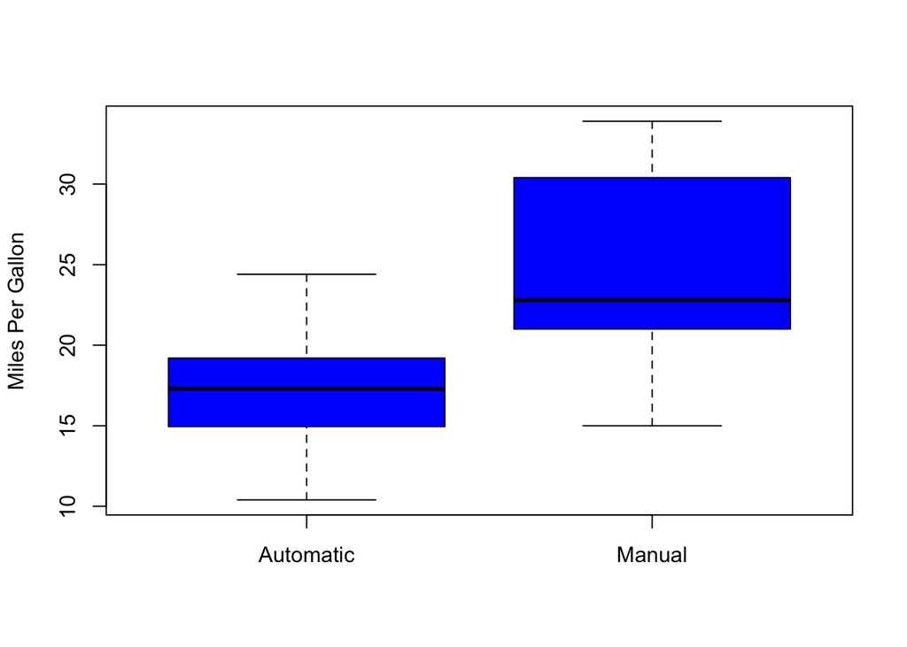